# Unsurprised

kelvin njunge

9/3/2021

# **Problem definition**

## ** a) Specifying the question**

Perform clustering stating analysis and visualizations.

## **b) Defining the metrics for success**

Bivariate and univariate Exploratory data analysis perform clustering stating insights drawn from your analysis and visualizations.

## **c) Understanding the context**

Kira Plastinina is a Russian brand that is sold through a defunct chain of retail stores in Russia, Ukraine, Kazakhstan, Belarus, China, Philippines, and Armenia. The brand’s Sales and Marketing team would like to understand their customer’s behavior from data that they have collected over the past year. More specifically, they would like to learn the characteristics of customer groups.

## **d) Recording the Experimental Design**

- Define the question, the metric for success, the context, experimental design taken.
- Read and explore the given dataset.
- Find and deal with outliers, anomalies, and missing data within the dataset.
- Perform univariate and bivariate analysis.
- Perform clustering stating insights drawn from your analysis and visualizations.

## **e) Relevance of the data**

The data used for this project is necessary for understanding their customer’s behavior from data that they have collected over the past year. More specifically, to learn the characteristics of customer groups.

## ** Data sourcing**

```r
library(data.table)
library(ggplot2)
library(dplyr)
library(psych)
```

## ** Importing data**

```r
df <- read.csv("C:\\Users\\Ricky\\Documents\\online_shoppers_intention.csv")
```

## **Previewing the top 6 entries**

```r
head(df)
```

```
##   Administrative Administrative_Duration Informational Informational_Duration
## 1              0                       0             0                      0
## 2              0                       0             0                      0
## 3              0                      -1             0                     -1
## 4              0                       0             0                      0
## 5              0                       0             0                      0
## 6              0                       0             0                      0
##   ProductRelated ProductRelated_Duration BounceRates ExitRates PageValues
## 1              1                0.000000  0.20000000 0.2000000          0
## 2              2               64.000000  0.00000000 0.1000000          0
## 3              1               -1.000000  0.20000000 0.2000000          0
## 4              2                2.666667  0.05000000 0.1400000          0
## 5             10              627.500000  0.02000000 0.0500000          0
## 6             19              154.216667  0.01578947 0.0245614          0
##   SpecialDay Month OperatingSystems Browser Region TrafficType
## 1          0   Feb                1       1      1           1
## 2          0   Feb                2       2      1           2
## 3          0   Feb                4       1      9           3
## 4          0   Feb                3       2      2           4
## 5          0   Feb                3       3      1           4
## 6          0   Feb                2       2      1           3
##         VisitorType Weekend Revenue
## 1 Returning_Visitor   FALSE   FALSE
## 2 Returning_Visitor   FALSE   FALSE
## 3 Returning_Visitor   FALSE   FALSE
## 4 Returning_Visitor   FALSE   FALSE
## 5 Returning_Visitor    TRUE   FALSE
## 6 Returning_Visitor   FALSE   FALSE
```

#### **Previewing the bottom 6 entries**

```r
tail(df)
```

```
##       Administrative Administrative_Duration Informational
## 12325              0                       0             1
## 12326              3                     145             0
## 12327              0                       0             0
## 12328              0                       0             0
## 12329              4                      75             0
## 12330              0                       0             0
##       Informational_Duration ProductRelated ProductRelated_Duration BounceRates
## 12325                      0             16                 503.000 0.000000000
## 12326                      0             53                1783.792 0.007142857
## 12327                      0              5                 465.750 0.000000000
## 12328                      0              6                 184.250 0.083333333
## 12329                      0             15                 346.000 0.000000000
## 12330                      0              3                  21.250 0.000000000
##        ExitRates PageValues SpecialDay Month OperatingSystems Browser Region
## 12325 0.03764706    0.00000          0   Nov                2       2      1
## 12326 0.02903061   12.24172          0   Dec                4       6      1
## 12327 0.02133333    0.00000          0   Nov                3       2      1
## 12328 0.08666667    0.00000          0   Nov                3       2      1
## 12329 0.02105263    0.00000          0   Nov                2       2      3
## 12330 0.06666667    0.00000          0   Nov                3       2      1
##       TrafficType       VisitorType Weekend Revenue
## 12325           1 Returning_Visitor   FALSE   FALSE
## 12326           1 Returning_Visitor    TRUE   FALSE
## 12327           8 Returning_Visitor    TRUE   FALSE
## 12328          13 Returning_Visitor    TRUE   FALSE
## 12329          11 Returning_Visitor   FALSE   FALSE
## 12330           2       New_Visitor    TRUE   FALSE
```

#### **Previewing the columns of our dataset**

```r
names(df)
```

```
##  [1] "Administrative"          "Administrative_Duration"
##  [3] "Informational"           "Informational_Duration"
##  [5] "ProductRelated"          "ProductRelated_Duration"
##  [7] "BounceRates"             "ExitRates"
##  [9] "PageValues"              "SpecialDay"
## [11] "Month"                   "OperatingSystems"
## [13] "Browser"                 "Region"
## [15] "TrafficType"             "VisitorType"
## [17] "Weekend"                 "Revenue"
```

## Data cleaning

### Completeness

```r
# checking for missing values
colSums(is.na(df))
```

```
##          Administrative Administrative_Duration           Informational
##                      14                      14                      14
##  Informational_Duration          ProductRelated ProductRelated_Duration
##                      14                      14                      14
##             BounceRates               ExitRates              PageValues
##                      14                      14                       0
##              SpecialDay                   Month        OperatingSystems
##                       0                       0                       0
##                 Browser                  Region             TrafficType
##                       0                       0                       0
##             VisitorType                 Weekend                 Revenue
##                       0                       0                       0
```

```r
getmode <- function(v){
  v=v[nchar(as.character(v))>0]
  uniqv <- unique(v)
  uniqv[which.max(tabulate(match(v, uniqv)))]}
```

```r
for (cols in colnames(df)) {
  if (cols %in% names(df[,sapply(df, is.numeric)])) {
    df<-df%>%mutate(!!cols := replace(!!rlang::sym(cols), is.na(!!rlang::sym(cols)), mean(!!rlang::sym(cols), na.rm=TRUE)))
  }
  else {
    df<-df%>%mutate(!!cols := replace(!!rlang::sym(cols), !!rlang::sym(cols)=="", getmode(!!rlang::sym(cols))))
  }
}
```

```r
colSums(is.na(df))
```

```
##          Administrative Administrative_Duration           Informational
##                       0                       0                       0
##  Informational_Duration          ProductRelated ProductRelated_Duration
##                       0                       0                       0
##             BounceRates               ExitRates              PageValues
##                       0                       0                       0
##              SpecialDay                   Month        OperatingSystems
##                       0                       0                       0
##                 Browser                  Region             TrafficType
##                       0                       0                       0
##             VisitorType                 Weekend                 Revenue
##                       0                       0                       0
```

### **Checking for duplicates**

```r
sum(duplicated(df))
```

```
## [1] 119
```

We have 119 duplicated rows

```r
# eliminating for duplicates
df <- df[!duplicated(df), ]
```

### ***checking for outliers**

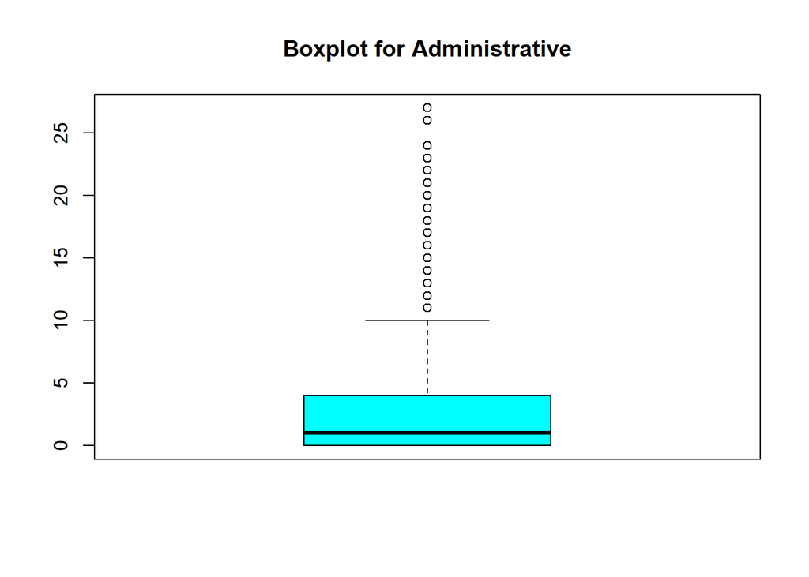

```r
boxplot(df$Administrative,main="Boxplot for Administrative",col = "cyan")
```

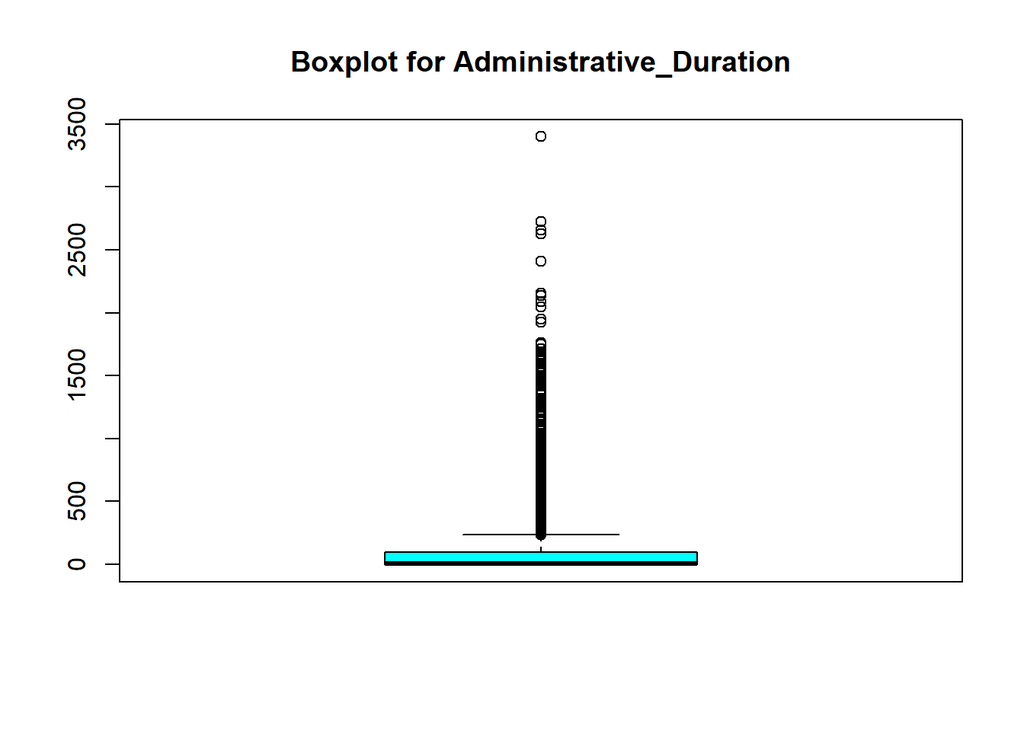

```r
boxplot(df$Administrative_Duration,main="Boxplot for Administrative_Duration",col = "cyan")
```

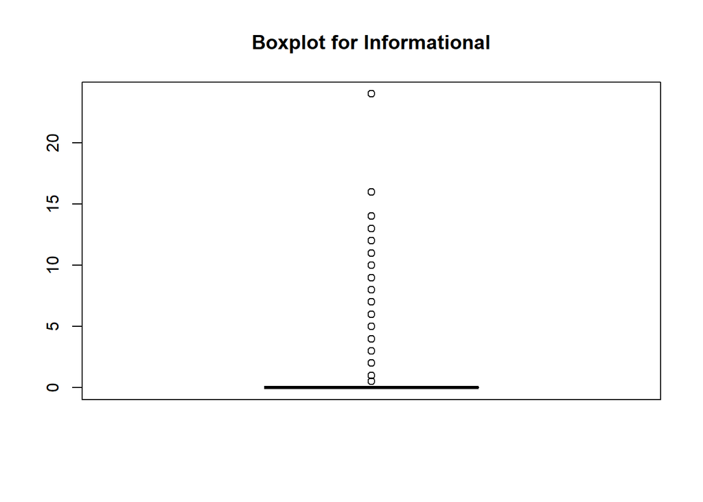

```r
boxplot(df$Informational,main="Boxplot for Informational",col = "cyan")
```

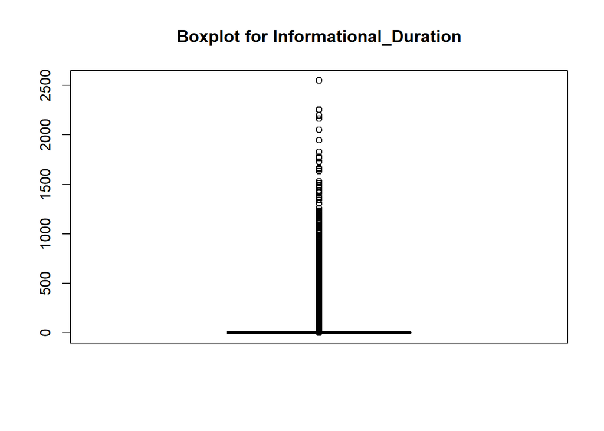

```r
boxplot(df$Informational_Duration,main="Boxplot for Informational_Duration",col = "cyan")
```

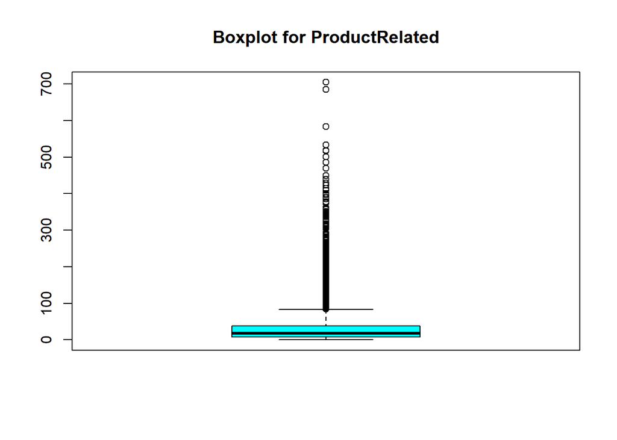

```r
boxplot(df$ProductRelated,main="Boxplot for ProductRelated",col = "cyan")
```

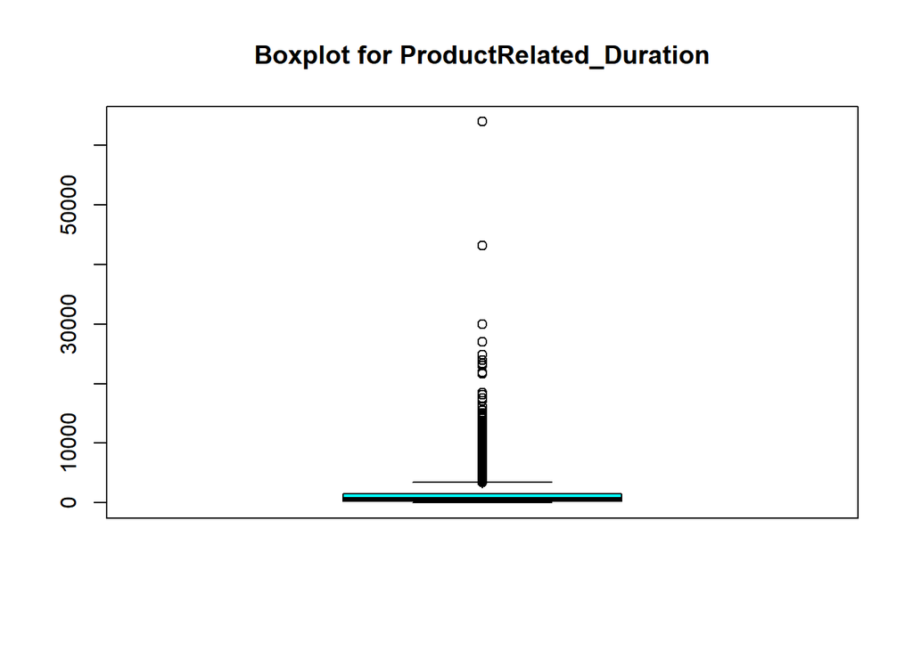

```r
boxplot(df$ProductRelated_Duration,main="Boxplot for ProductRelated_Duration",col = "cyan")
```

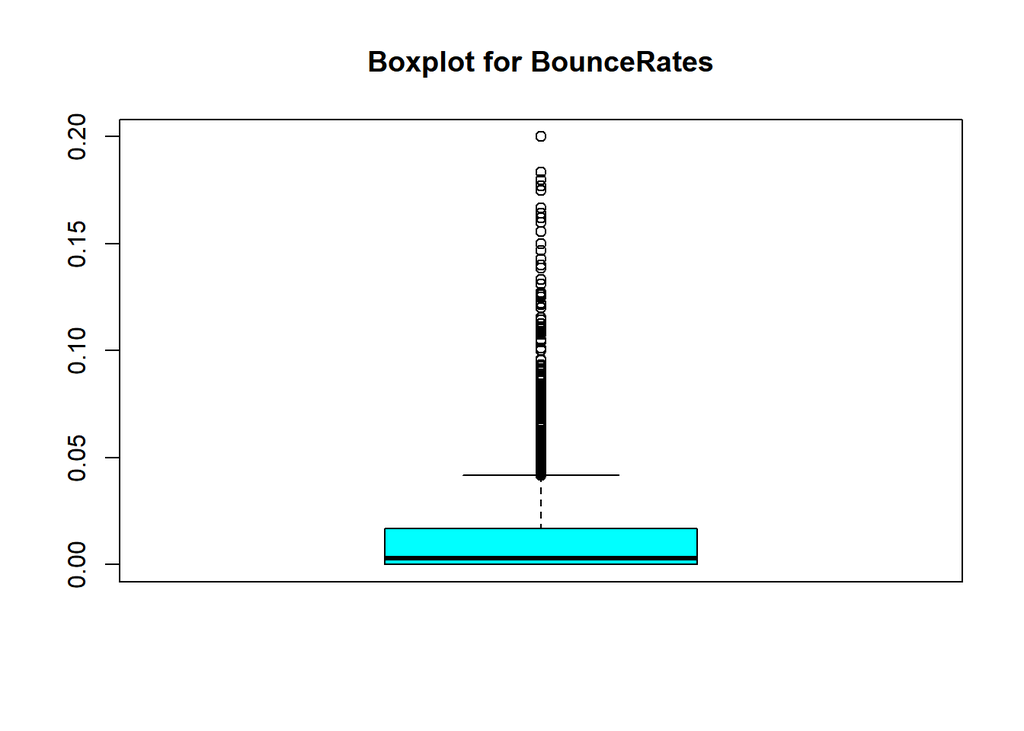

```r
boxplot(df$BounceRates,main="Boxplot for BounceRates",col = "cyan")
```

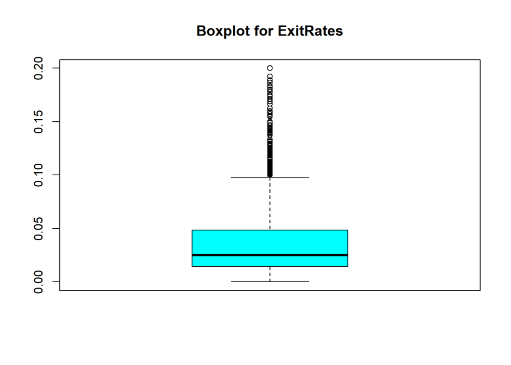

```r
boxplot(df$ExitRates,main="Boxplot for ExitRates",col = "cyan")
```

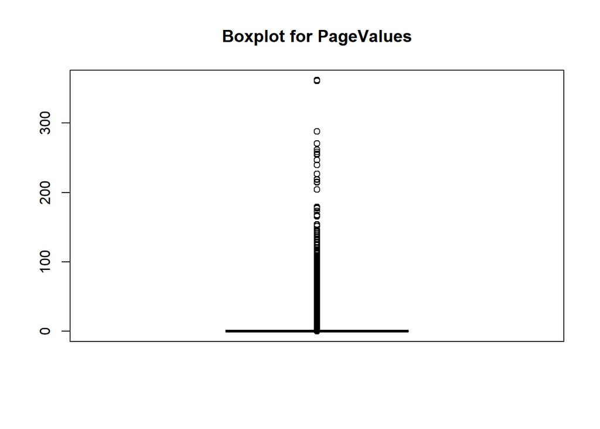

```r
boxplot(df$PageValues,main="Boxplot for PageValues",col = "cyan")
```

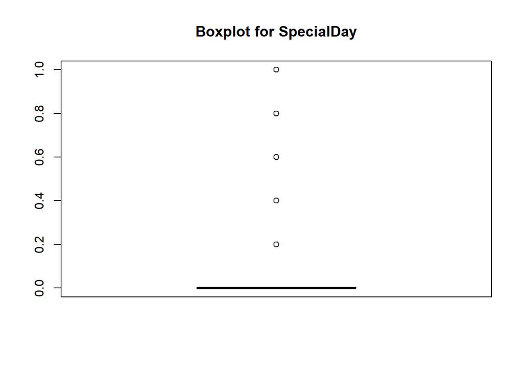

```r
boxplot(df$SpecialDay,main="Boxplot for SpecialDay",col = "cyan")
```

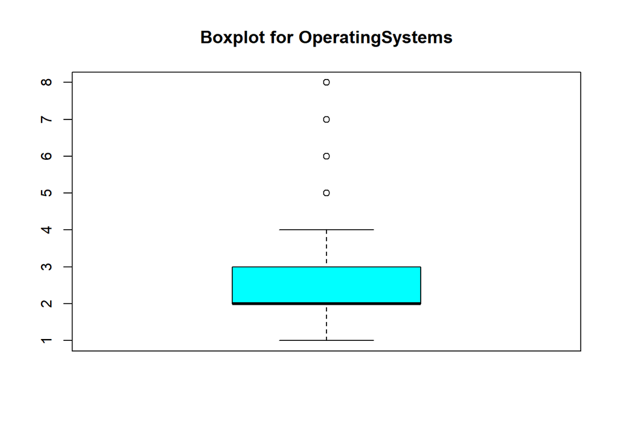

```r
boxplot(df$OperatingSystems,main="Boxplot for OperatingSystems",col = "cyan")
boxplot(df$OperatingSystems,main="Boxplot for OperatingSystems",col = "cyan")
```

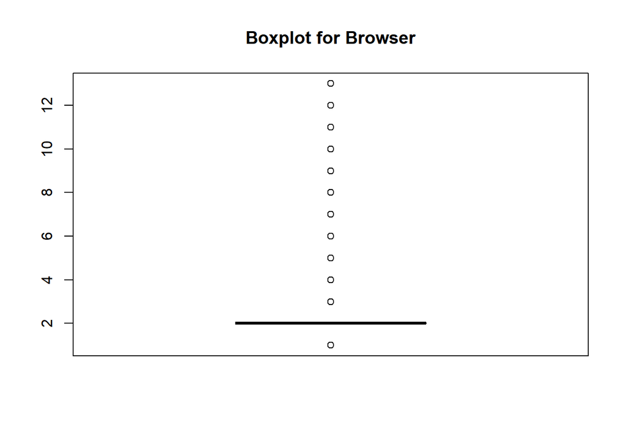

```r
boxplot(df$Browser,main="Boxplot for Browser",col = "cyan")
```

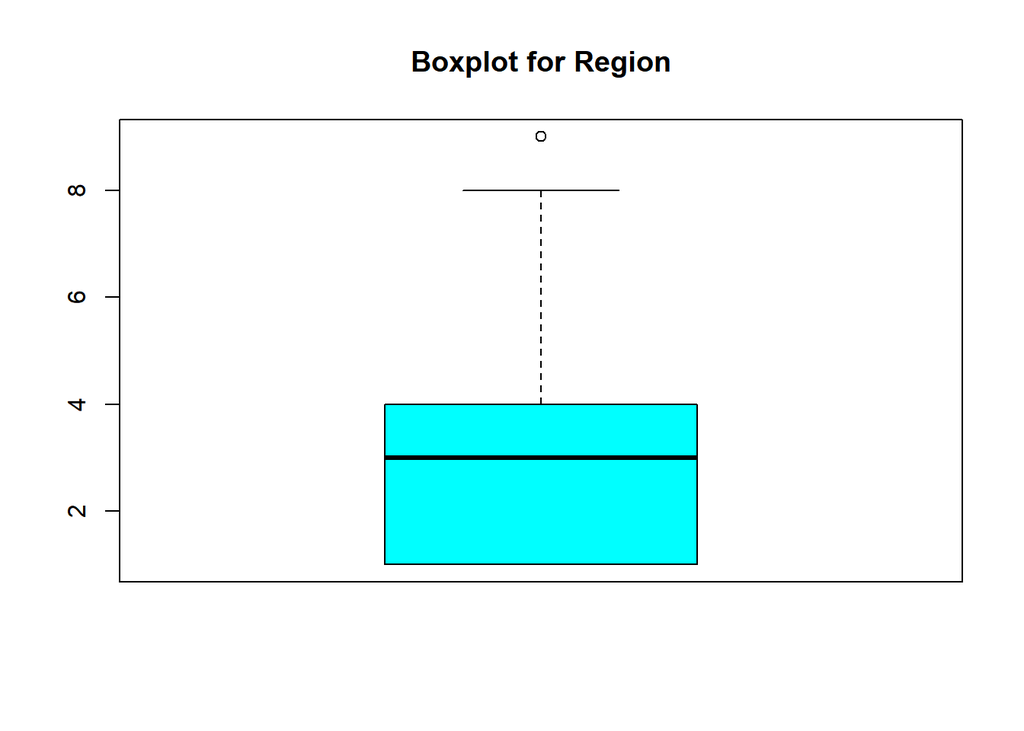

```r
boxplot(df$Region,main="Boxplot for Region",col = "cyan")
boxplot(df$Region,main="Boxplot for Region",col = "cyan")
```

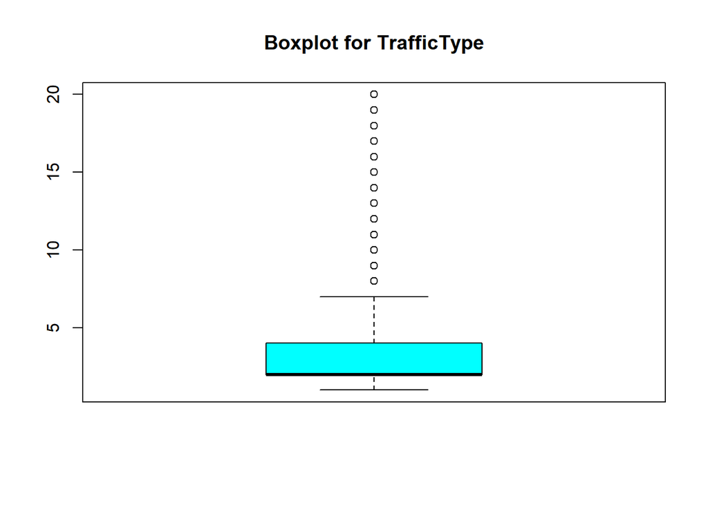

```r
boxplot(df$TrafficType,main="Boxplot for TrafficType",col = "cyan")
```

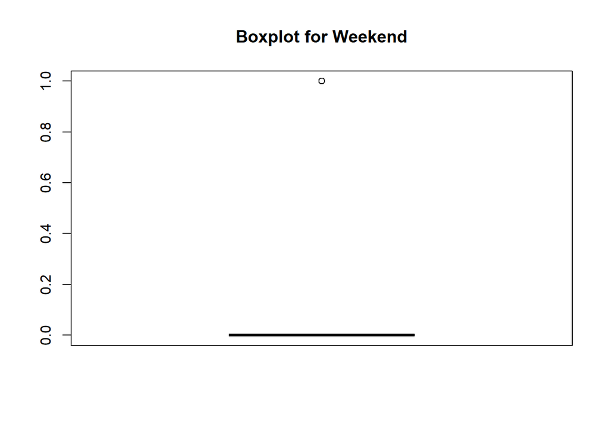

```r
boxplot(df$Weekend,main="Boxplot for Weekend",col = "cyan")
```

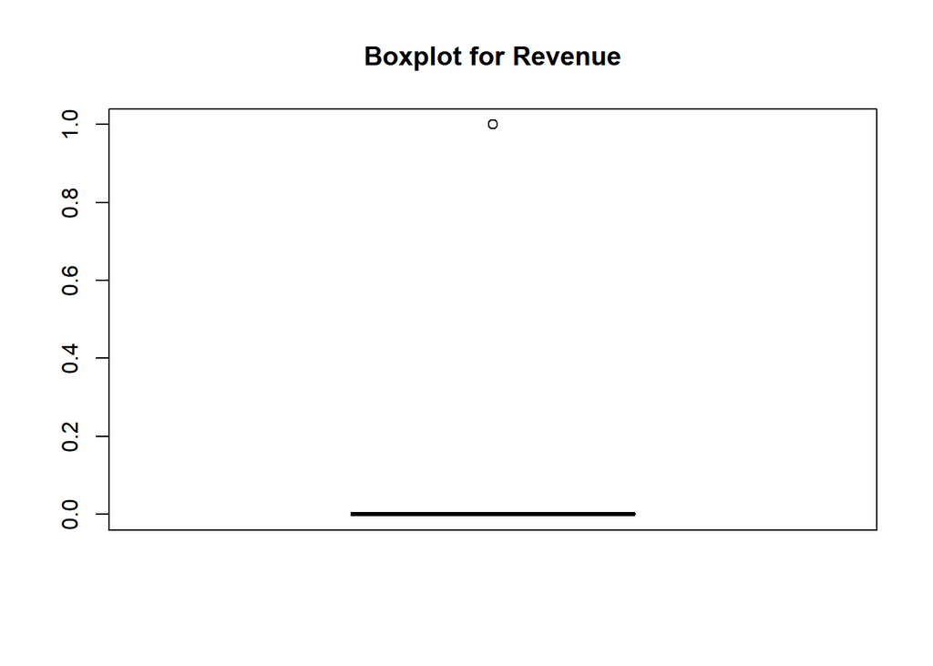

```r
boxplot(df$Revenue,main="Boxplot for Revenue",col = "cyan")
```

### 4. Univariate

#### Measures of central tendency

```r
cat("The mean for Administrative is",mean(df$Administrative))
```

```
## The mean for Administrative is 2.340006
```

```r
cat("\n")
```

```r
cat("The mean for Administrative_Duration is",mean(df$Administrative_Duration))
```

```
## The mean for Administrative_Duration is 81.68138
```

```r
cat("\n")
```

```r
cat("The mean for Informational is",mean(df$Informational))
```

```
## The mean for Informational is 0.5088074
```

```r
cat("\n")
```

```r
cat("The mean for Informational_Duration is",mean(df$Informational_Duration))
```

```
## The mean for Informational_Duration is 34.83701
```

```r
cat("\n")
```

```r
cat("The mean for ProductRelated is",mean(df$ProductRelated))
```

```
## The mean for ProductRelated is 32.05816
```

```r
cat("\n")
```

```r
cat("The mean for ProductRelated_Duration is",mean(df$ProductRelated_Duration))
```

```
## The mean for ProductRelated_Duration is 1207.497
```

```r
cat("\n")
```

```r
cat("The mean for BounceRates is",mean(df$BounceRates))
```

```
## The mean for BounceRates is 0.02044841
```

```r
cat("\n")
```

```r
cat("The mean for ExitRates is",mean(df$ExitRates))
```

```
## The mean for ExitRates is 0.04149826
```

```r
cat("\n")
```

```r
cat("The mean for PageValues is",mean(df$PageValues))
```

```
## The mean for PageValues is 5.946651
```

```r
cat("\n")
```

```r
cat("The mean for SpecialDay is",mean(df$SpecialDay))
```

```
## The mean for SpecialDay is 0.06191139
```

```r
cat("\n")
```

```r
cat("The mean for OperatingSystems is",mean(df$OperatingSystems))
```

```
## The mean for OperatingSystems is 2.124232
```

```r
cat("\n")
```

```r
cat("The mean for Browser is",mean(df$Browser))
```

```
## The mean for Browser is 2.35771
```

```r
cat("\n")
```

```r
cat("The mean for Region is",mean(df$Region))
```

```
## The mean for Region is 3.152977
```

```r
cat("\n")
```

```r
cat("The mean for TrafficType is",mean(df$TrafficType))
```

```
## The mean for TrafficType is 4.074032
```

```r
cat("\n")
```

```r
cat("The mean for Weekend is",mean(df$Weekend))
```

```
## The mean for Weekend is 0.2341332
```

```r
cat("\n")
```

```r
cat("The mean for Revenue is",mean(df$Revenue))
```

```
## The mean for Revenue is 0.1562526
```

##### *Median*

```r
cat("The median for Administrative is",median(df$Administrative))
```

```
## The median for Administrative is 1
```

```r
cat("\n")
```

```r
cat("The median for Administrative_Duration is",mean(df$Administrative_Duration))
```

[output not shown]

```r
cat("\n")
```

```r
cat("The median for Informational is",median(df$Informational))
```

```
## The median for Informational is 0
```

```r
cat("\n")
```

```r
cat("The median for Informational_Duration is",mean(df$Informational_Duration))
```

[output not shown]

```r
cat("\n")
```

```r
cat("The median for ProductRelated is",median(df$ProductRelated))
```

```
## The median for ProductRelated is 18
```

```r
cat("\n")
```

```r
cat("The median for ProductRelated_Duration is",median(df$ProductRelated_Duration))
```

```
## The median for ProductRelated_Duration is 611
```

```r
cat("\n")
```

```r
cat("The median for BounceRates is",median(df$BounceRates))
```

```
## The median for BounceRates is 0.002941176
```

```r
cat("\n")
```

```r
cat("The median for ExitRates is",median(df$ExitRates))
```

```
## The median for ExitRates is 0.025
```

```r
cat("\n")
```

```r
cat("The median for PageValues is",median(df$PageValues))
```

```
## The median for PageValues is 0
```

```r
cat("\n")
```

```r
cat("The median for SpecialDay is",median(df$SpecialDay))
```

```
## The median for SpecialDay is 0
```

```r
cat("\n")
```

```r
cat("The median for OperatingSystems is",median(df$OperatingSystems))
```

```
## The median for OperatingSystems is 2
```

```r
cat("\n")
```

```r
cat("The median for Browser is",median(df$Browser))
```

```
## The median for Browser is 2
```

```r
cat("\n")
```

```r
cat("The median for Region is",median(df$Region))
```

```
## The median for Region is 3
```

```r
cat("\n")
```

```r
cat("The median for TrafficType is",median(df$TrafficType))
```

```
## The median for TrafficType is 2
```

```r
cat("\n")
```

```r
cat("The median for Weekend is",median(df$Weekend))
```

```
## The median for Weekend is FALSE
```

```r
cat("\n")
```

```r
cat("The median for Revenue is",median(df$Revenue))
```

```
## The median for Revenue is FALSE
```

```r
cat("\n")
```

### **Mode**

```r
getmode <- function(v) {
   uniqv <- unique(v)
   uniqv[which.max(tabulate(match(v, uniqv)))]}
```

```r
cat("The mode for Administrative is",getmode(df$Administrative))
```

```
## The mode for Administrative is 0
```

```r
cat("\n")
```

```r
cat("The mode for Administrative_Duration is",getmode(df$Administrative_Duration))
```

```
## The mode for Administrative_Duration is 0
```

```r
cat("\n")
```

```r
cat("The mode for Informational is",getmode(df$Informational))
```

```
## The mode for Informational is 0
```

```r
cat("\n")
```

```r
cat("The mode for Informational_Duration is",getmode(df$Informational_Duration))
```

```
## The mode for Informational_Duration is 0
```

```r
cat("\n")
```

```r
cat("The mode for ProductRelated is",getmode(df$ProductRelated))
```

```
## The mode for ProductRelated is 1
```

```r
cat("\n")
```

```r
cat("The mode for ProductRelated_Duration is",getmode(df$ProductRelated_Duration))
```

```
## The mode for ProductRelated_Duration is 0
```

```r
cat("\n")
```

```r
cat("The mode for BounceRates is",getmode(df$BounceRates))
```

```
## The mode for BounceRates is 0
```

```r
cat("\n")
```

```r
cat("The mode for ExitRates is",getmode(df$ExitRates))
```

```
## The mode for ExitRates is 0.2
```

```r
cat("\n")
```

```r
cat("The mode for PageValues is",getmode(df$PageValues))
```

```
## The mode for PageValues is 0
```

```r
cat("\n")
```

```r
cat("The mode for SpecialDay is",getmode(df$SpecialDay))
```

```
## The mode for SpecialDay is 0
```

```r
cat("\n")
```

```r
cat("The mode for OperatingSystems is",getmode(df$OperatingSystems))
```

```
## The mode for OperatingSystems is 2
```

```r
cat("\n")
```

```r
cat("The mode for Browser is",getmode(df$Browser))
```

```
## The mode for Browser is 2
```

```r
cat("\n")
```

```r
cat("The mode for Region is",getmode(df$Region))
```

```
## The mode for Region is 1
```

```r
cat("\n")
```

```r
cat("The mode for TrafficType is",getmode(df$TrafficType))
```

```
## The mode for TrafficType is 2
```

```r
cat("\n")
```

#### **Standard deviation**

```r
cat("The standard deviation for Administrative is",sd(df$Administrative))
```

```
## The standard deviation for Administrative is 3.329214
```

```r
cat("\n")
```

```r
cat("The standard deviation for Administrative_Duration is",sd(df$Administrative_Duration))
```

```
## The standard deviation for Administrative_Duration is 177.4409
```

```r
cat("\n")
```

```r
cat("The standard deviation for Informational is",sd(df$Informational))
```

```
## The standard deviation for Informational is 1.27519
```

```r
cat("\n")
```

```r
cat("The standard deviation for Informational_Duration is",sd(df$Informational_Duration))
```

```
## The standard deviation for Informational_Duration is 141.389
```

```r
cat("\n")
```

```r
cat("The standard deviation for ProductRelated is",sd(df$ProductRelated))
```

```
## The standard deviation for ProductRelated is 44.57899
```

```r
cat("\n")
```

```r
cat("The standard deviation for ProductRelated_Duration is",sd(df$ProductRelated_Duration))
```

```
## The standard deviation for ProductRelated_Duration is 1918.984
```

```r
cat("\n")
```

```r
cat("The standard deviation for BounceRates is",sd(df$BounceRates))
```

```
## The standard deviation for BounceRates is 0.04538022
```

```r
cat("\n")
```

```r
cat("The standard deviation for ExitRates is",sd(df$ExitRates))
```

```
## The standard deviation for ExitRates is 0.04622445
```

```r
cat("\n")
```

```r
cat("The standard deviation for PageValues is",sd(df$PageValues))
```

```
## The standard deviation for PageValues is 18.64955
```

```r
cat("\n")
```

```r
cat("The standard deviation for SpecialDay is",sd(df$SpecialDay))
```

```
## The standard deviation for SpecialDay is 0.1996219
```

```r
cat("\n")
```

```r
cat("The standard deviation for OperatingSystems is",sd(df$OperatingSystems))
```

```
## The standard deviation for OperatingSystems is 0.9068192
```

```r
cat("\n")
```

```r
cat("The standard deviation for Browser is",sd(df$Browser))
```

```
## The standard deviation for Browser is 1.709958
```

```r
cat("\n")
```

```r
cat("The standard deviation for Region is",sd(df$Region))
```

```
## The standard deviation for Region is 2.401853
```

```r
cat("\n")
```

```r
cat("The standard deviation for TrafficType is",sd(df$TrafficType))
```

```
## The standard deviation for TrafficType is 4.016643
```

```r
cat("\n")
```

#### ***Variance**

```r
cat("The Variance for Administrative is",var(df$Administrative))
```

```
## The Variance for Administrative is 11.08367
```

```r
cat("\n")
```

```r
cat("The Variance for Administrative_Duration is",var(df$Administrative_Duration))
```

```
## The Variance for Administrative_Duration is 31485.28
```

```r
cat("\n")
```

```r
cat("The Variance for Informational is",var(df$Informational))
```

```
## The Variance for Informational is 1.62611
```

```r
cat("\n")
```

```r
cat("The Variance for Informational_Duration is",var(df$Informational_Duration))
```

```
## The Variance for Informational_Duration is 19990.84
```

```r
cat("\n")
```

```r
cat("The Variance for ProductRelated is",var(df$ProductRelated))
```

```
## The Variance for ProductRelated is 1987.286
```

```r
cat("\n")
```

```r
cat("The Variance for ProductRelated_Duration is",var(df$ProductRelated_Duration))
```

```
## The Variance for ProductRelated_Duration is 3682499
```

```r
cat("\n")
```

```r
cat("The Variance for BounceRates is",var(df$BounceRates))
```

```
## The Variance for BounceRates is 0.002059364
```

```r
cat("\n")
```

```r
cat("The Variance for ExitRates is",var(df$ExitRates))
```

```
## The Variance for ExitRates is 0.0021367
```

```r
cat("\n")
```

```r
cat("The Variance for PageValues is",var(df$PageValues))
```

```
## The Variance for PageValues is 347.8058
```

```r
cat("\n")
```

```r
cat("The Variance for SpecialDay is",var(df$SpecialDay))
```

```
## The Variance for SpecialDay is 0.03984889
```

```r
cat("\n")
```

```r
cat("The Variance for OperatingSystems is",var(df$OperatingSystems))
```

```
## The Variance for OperatingSystems is 0.822321
```

```r
cat("\n")
```

```r
cat("The Variance for Browser is",var(df$Browser))
```

```
## The Variance for Browser is 2.923958
```

```r
cat("\n")
```

```r
cat("The Variance for Region is",var(df$Region))
```

```
## The Variance for Region is 5.768898
```

```r
cat("\n")
```

```r
cat("The Variance for TrafficType is",var(df$TrafficType))
```

```
## The Variance for TrafficType is 16.13342
```

```r
cat("\n")
```

### *Measures of Dispersion*

#### *Minimum*

```r
library(dplyr)
df %>% summarise_if(is.numeric,min)
```

```
##   Administrative Administrative_Duration Informational Informational_Duration
## 1              0                      -1             0                     -1
##   ProductRelated ProductRelated_Duration BounceRates ExitRates PageValues
## 1              0                      -1           0         0          0
##   SpecialDay OperatingSystems Browser Region TrafficType
## 1          0                1       1      1           1
```

#### *Maximum*

```r
#Maximum of the columns
df %>% summarise_if(is.numeric,max)
```

```
##   Administrative Administrative_Duration Informational Informational_Duration
## 1             27                 3398.75            24               2549.375
##   ProductRelated ProductRelated_Duration BounceRates ExitRates PageValues
## 1            705                63973.52         0.2       0.2   361.7637
##   SpecialDay OperatingSystems Browser Region TrafficType
## 1          1                8      13      9          20
```